# MacLeish Layers

Esa Schenck

2022-08-02

# Intro to MacLeish

This package is maintained by Ben Baumer (a Smith professor) and was created by:

- Ben Baumer
- Rose Goueth
- Wencong Li
- Weijia Zhang
- Nicholas Horton
- Dominique Kelly
- Albert Y. Kim

This presentation was adapted from a lab created by Ben Baumer.

# Getting Set Up

We’re going to use the packages `tidyverse`, `macleish`, and `sf`.

```r
library(tidyverse)
library(macleish)
library(sf)
```

# How do we use the `macleish` package?

The data included in this package are:

- etl_extract.etl_macleish
- macleish_layers
- maple_sap
- mass_gis
- phenocam_image_url
- tree_diameter1
- tree_diameter2
- whately_2015

Let’s explore a couple of those.

# `tree_diameter1`

Let’s view some data from `tree_diameter1`

```
## # A tibble: 6 × 5
##   species         position  semester  year diameter
##   <chr>           <chr>     <chr>    <dbl>    <dbl>
## 1 Eastern Hemlock subcanopy Fall      2015     10.5
## 2 Eastern Hemlock subcanopy Fall      2014     10.4
## 3 Eastern Hemlock subcanopy Fall      2013     10.5
## 4 Eastern Hemlock subcanopy Fall      2012     10.4
## 5 Eastern Hemlock subcanopy Fall      2011     10.2
## 6 Eastern Hemlock subcanopy Fall      2010     10.1
```

# Summary of `tree_diameter1`

```
##    species            position           semester              year
##  Length:919         Length:919         Length:919         Min.   :2010
##  Class :character   Class :character   Class :character   1st Qu.:2011
##  Mode  :character   Mode  :character   Mode  :character   Median :2012
##                                                           Mean   :2012
##                                                           3rd Qu.:2014
##                                                           Max.   :2015
##     diameter
##  Min.   : 0.40
##  1st Qu.: 5.60
##  Median :14.10
##  Mean   :15.54
##  3rd Qu.:23.25
##  Max.   :54.50
```

# Working with Spatial Data

We’re already familiar with data such as that found in `tree_diameter1`, but so far in this class we haven’t worked with spatial data.

## What IS spatial data?

Spatial data describes locations and geography – i.e., the physical SPACE in which we live.

## How do we use spatial data?

We can analyze spatial data with the `sf` package in R. `sf` adds options to `ggplot2`, meaning that you can create a `geom_sf()` object in ggplot.

# `macleish_layers` and `pluck()`

The package `macleish` contains a list which stores the spatial data. This list is called `macleish_layers`. To access these spatial layers, we use the `pluck()` function.

The layers stored here are:

- landmarks
- forests
- streams
- challenge_courses
- buildings
- wetlands
- boundary
- research
- soil
- trails
- camp_sites
- elevation

# MacLeish Trails

```r
macleish_layers %>%
  pluck("trails")
```

```
## Simple feature collection with 15 features and 2 fields
## Geometry type: LINESTRING
## Dimension:     XY
## Bounding box:  xmin: -72.68513 ymin: 42.44177 xmax: -72.67731 ymax: 42.4618
## Geodetic CRS:  WGS 84
## First 10 features:
##                name  color                       geometry
## 1   Porcupine Trail  White LINESTRING (-72.68291 42.45...
## 2      Western Loop    Red LINESTRING (-72.68111 42.45...
## 3  Poplar Hill Road   Road LINESTRING (-72.68155 42.45...
## 4  Vernal Pool Loop Yellow LINESTRING (-72.68265 42.44...
## 5      Eastern Loop   Blue LINESTRING (-72.68113 42.45...
## 6      Western Loop    Red LINESTRING (-72.68401 42.45...
## 7      Western Loop    Red LINESTRING (-72.68088 42.44...
## 8       entry trail      - LINESTRING (-72.68088 42.44...
## 9      Eastern Loop   Blue LINESTRING (-72.68063 42.45...
## 10         Easy Out    Red LINESTRING (-72.67962 42.45...
```

# Mapping MacLeish trails with plot()

We can use the plot() function to make a basic plot of a layer, such as trails.

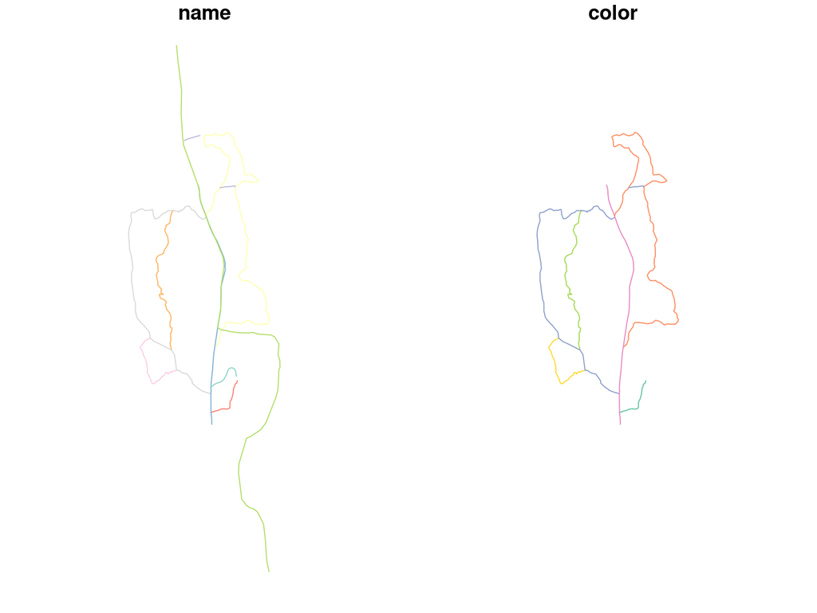

```r
macleish_layers %>%
  pluck("trails") %>%
  plot()
```

# Mapping with geom_sf()

Once you’ve plucked a layer, you can add a `geom_sf()` object.

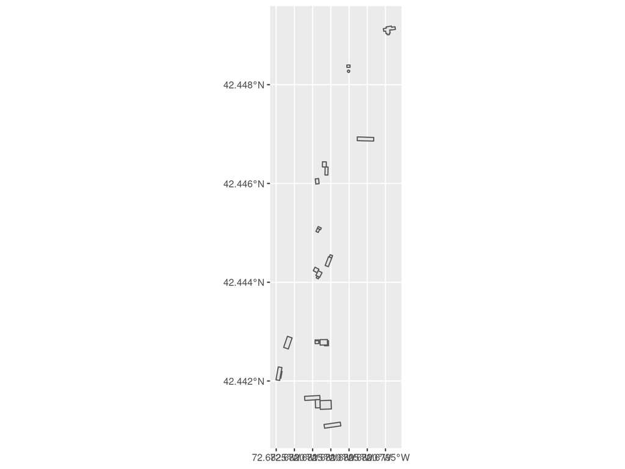

```r
macleish_layers %>%
  pluck("buildings") %>%
  ggplot() +
  geom_sf()
```

# Mapping more than one object

Instead of piping, use the `data` argument in each `geom_sf()`. This plot shows both the buildings and trails of MacLeish:

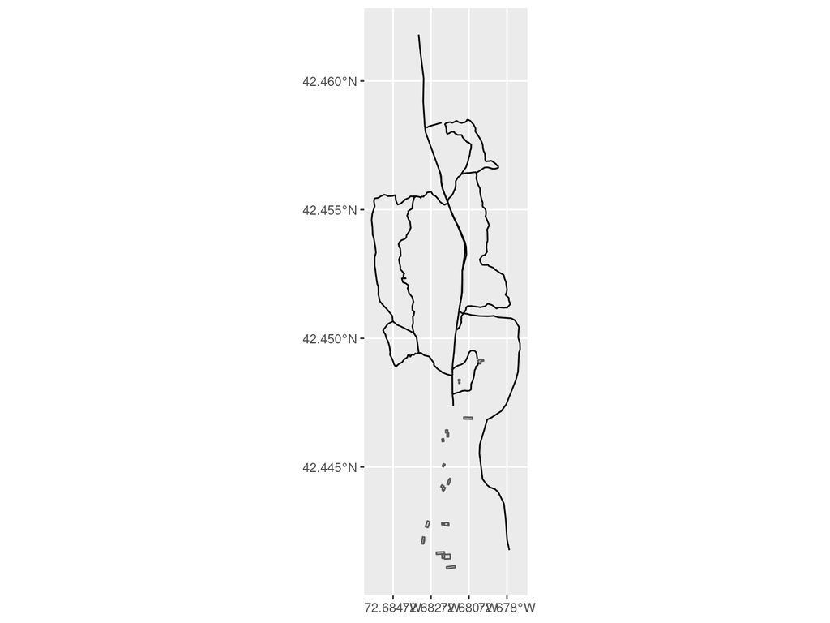

```r
ggplot() +
  geom_sf(data = pluck(macleish_layers, "buildings")) +
  geom_sf(data = pluck(macleish_layers, "trails"), color = "black")
```

# Creating interactive maps with `leaflet`

Here we create the spatial object bechtel, to represent the Bechtel Environmental Classroom, and then create a leaflet interactive map with a popup marker.

```r
library(leaflet)

# latitude and longitude of the Bechtel Classroom
bechtel <- tibble(lat = 42.449167, lon = -72.679389)

base_plot <- leaflet() %>%
  addTiles() %>%                                    # creates the map
  addMarkers(                                       # creates a marker on the classroom
    lng = ~lon, lat = ~lat, data = bechtel,         # lat and long of the classroom from "bechtel"
    popup = "Bechtel Environmental Classroom"       # label
  )
```

# Bechtel Environmental Classroom

[interactive chart not shown]

# Add polygons to view more of the data

```r
base_plot %>%                                 # base_plot is the interactive map
  addPolygons(                                # polygons are layers of spatial data
    data = macleish_layers[["trails"]],       # using the trail data
    weight = 1, popup = ~name
  )
```

[interactive chart not shown]